# HW2-Hyungjoo

```python
import numpy as np
import random
from numpy.linalg import*
import matplotlib.pyplot as plt
from numpy import r_, exp, cos, sin, pi, zeros, ones, hanning, sqrt, log, floor, reshape, mean
from scipy import signal,stats
from numpy.fft import fft
import math
import time

import scipy.io as sio
import scipy.io.wavfile
import sounddevice as sd
from IPython.display import Audio

import copy
%matplotlib inline
import librosa
import librosa.display


def BGR2RGB(X):
    return cv2.cvtColor(X, cv2.COLOR_BGR2RGB)
def vec(X):
    return np.reshape(X,-1,order='F')
def vec_tran(X,a):    ## Only take matrix as input
    m, n = X.shape
    X_vt = np.zeros((a*n,int(m/a)))
    for i in range(len(X[0,:])):
        #X_vt[a*i:a*(i+1),:] = np.reshape(X[:,a*i:a*(i+1)],(a,-1),order='F')
        X_vt[a*i:a*(i+1),:]=np.reshape(X[:,i:i+1],(a,-1),order='F')
    return X_vt
```

[output not shown]

```
(513, 349)
```

[interactive chart not shown]

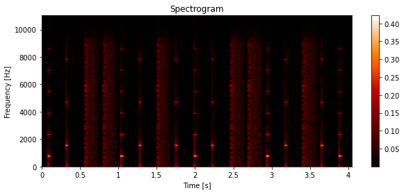

```python
## P1. Audio Feature Project

## Read audio file
x, fs = librosa.load('./HW2_data/Vl1.wav', sr=None)
N_fft = 1024
N_hop = 0.25*N_fft
f,t,X_ft = signal.stft(x, fs, window = 'hamming', nperseg=N_fft, noverlap = N_fft-N_hop)
X = np.abs(X_ft)
print(X_mag.shape)
X_plot = np.sqrt(X)
plt.figure(figsize=(10,4))
librosa.display.specshow(X_plot, sr=fs, x_axis='time', y_axis='linear', hop_length=N_hop ,cmap=plt.cm.gist_heat)
plt.xlabel("Time [s]")
plt.ylabel("Frequency [Hz]")
plt.colorbar()
plt.title("Spectrogram")
Audio(x, rate=fs)
```

As an be seen above, I, human, can tell by loooking that there are at least 3 different types of pattern of spectrum per a time chunk.

```
(513, 513)
(513, 3)
[[19.47214573  0.          0.        ]
 [ 0.         24.37693156  0.        ]
 [ 0.          0.         30.53972232]]
Cov(Z) =
 [[ 1.00287355e+00 -9.27363372e-09 -2.56915767e-09]
 [-9.27363372e-09  1.00287357e+00 -9.46086665e-09]
 [-2.56915767e-09 -9.46086665e-09  1.00287357e+00]]
```

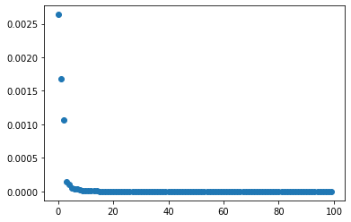

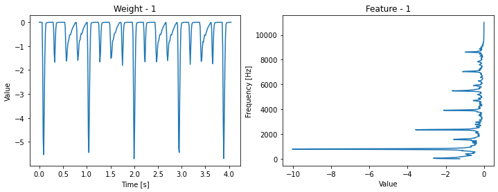

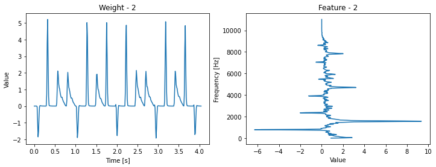

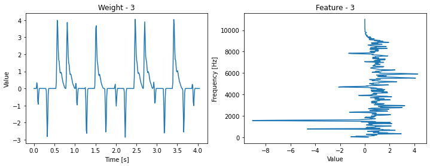

```python
##### P1.1: PCA #####
# Z = WX
# where Z: weight matrix (3 x 349), W: feature matrix (3 x 513), X: input matrix (513 x 349)
def center(X):
    mean = np.mean(X, axis=1, keepdims=True)
    centered =  X - mean
    return centered
X_mean = center(X)
X_cov = np.cov(X_mean, bias =True)
print(X_cov.shape)
EigVal, EigVec = np.linalg.eigh(X_cov)

sort_ind = np.argsort(EigVal)[::-1]
EigVal_sort = EigVal[sort_ind]
EigVec_sort = EigVec[:,sort_ind]
Disp = 100
plt.figure(0)
plt.plot(EigVal_sort[:Disp],'o')
N_sel = 3

EigVec_sel = EigVec_sort[:,:N_sel]
print(EigVec_sel.shape)

SigmaInv_sel = np.diag(1/np.sqrt(EigVal_sort[:N_sel]))
print(SigmaInv_sel)
W_sel = SigmaInv_sel@np.transpose(EigVec_sel)
X_sel = W_sel@X
print('Cov(Z) = \n',np.cov(Z_sel))

for i in range(N_sel):
    plt.figure(i+1,figsize=(12,4))
    plt.subplot(1,2,1)
    plt.plot(t,X_sel[i,:])
    plt.xlabel("Time [s]")
    plt.ylabel("Value")
    plt.title("Weight - %d"%(i+1))
    plt.subplot(1,2,2)
    plt.plot(W_sel[i,:],f)
    plt.ylabel("Frequency [Hz]")
    plt.xlabel("Value")
    plt.title("Feature - %d"%(i+1))
```

```
Cov(Y) =
 [[ 3.97521475 -0.27400391 -0.29531818]
 [-0.27400391  3.97632989 -0.27273476]
 [-0.29531818 -0.27273476  1.23401996]]
```

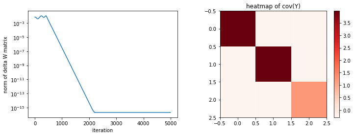

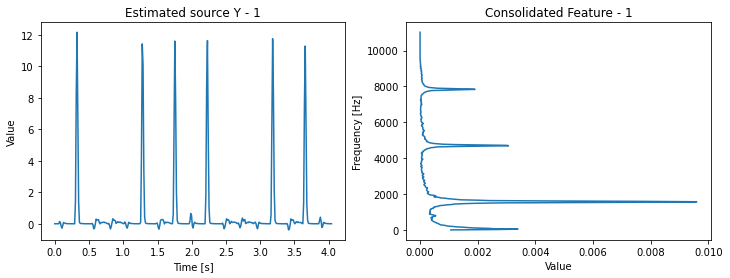

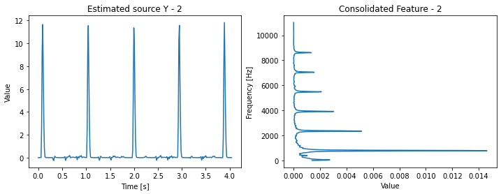

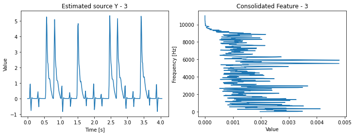

```python
##### P1.2: ICA #####
# Now, we start from X_sel from PCA output result.
# Y = W_ica X_sel
# where Y: Source estimates (3 x 349), W_ica: feature matrix (3 x 3), X_sel: input matrix (3 x 349)
N_iter = 5000
W_ica = np.random.rand(N_sel,N_sel) - 0.5
lr = 5e-5
N_t = len(X_sel[0,:])
dW_norm = []
for i in range(N_iter):
    dW = lr*(N_t*np.eye(N_sel)-2*np.tanh(W_ica@X_sel)@np.transpose(W_ica@X_sel))@W_ica
    W_ica = W_ica + dW
    dW_norm.append(np.linalg.norm(dW))

Y = W_ica@X_sel

plt.figure(0,figsize=(12,4))
plt.subplot(1,2,1)
plt.plot(dW_norm)
plt.xlabel('iteration')
plt.ylabel('norm of delta W matrix')
plt.yscale('log')

plt.subplot(1,2,2)
plt.imshow(np.cov(Y),cmap='Reds')
plt.colorbar()
plt.title('heatmap of cov(Y)')


print('Cov(Y) = \n',np.cov(Y))
W_ip = W_ica@W_sel
A_ip = np.linalg.pinv(W_ip) ## Mixing matrix
for i in range(N_sel):
    plt.figure(i+1,figsize=(12,4))
    plt.subplot(1,2,1)
    plt.plot(t,Y[i,:])
    plt.xlabel("Time [s]")
    plt.ylabel("Value")
    plt.title("Estimated source Y - %d"%(i+1))
    plt.subplot(1,2,2)
    plt.plot(A_ip[:,i],f)
    plt.ylabel("Frequency [Hz]")
    plt.xlabel("Value")
    plt.title("Consolidated Feature - %d"%(i+1))
```

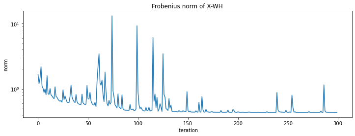

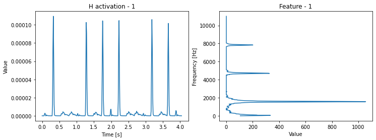

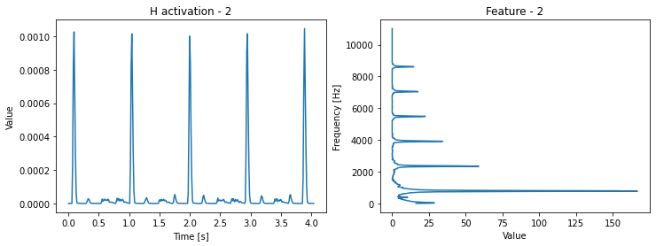

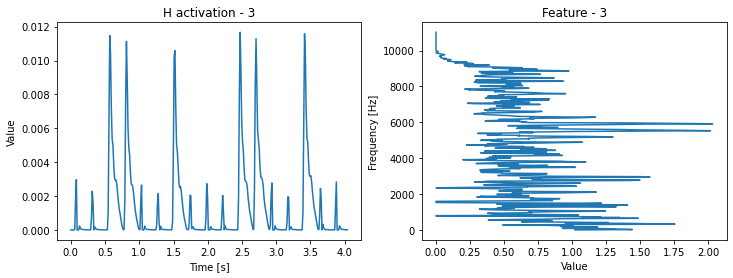

```python
##### P1.3: NMF #####
# This time, no need for PCA
# X = W_n H_n
# where X: Source estimates (513 x 349), W_n: feature matrix (513 x R), H_n: activation (R x 349)

## We pick R = N_sel ##
W_n = np.random.rand(len(X[:,0]),N_sel) - 0.5
H_n = np.random.rand(N_sel,len(X[0,:])) - 0.5
N_iter = 300
N_t = len(X_sel[0,:])
NMF_norm = []
for i in range(N_iter):
    ## H update
    H_n = H_n*(np.transpose(W_n)@X)/(np.transpose(W_n)@W_n@H_n + 1e-6)    ## small number added in denominator

    ## W update
    W_n = W_n*(X@np.transpose(H_n))/(W_n@H_n@np.transpose(H_n) + 1e-6)

    ## norm save
    NMF_norm.append(np.linalg.norm(X-W_n@H_n))

plt.figure(0,figsize=(12,4))
plt.plot(NMF_norm)
plt.xlabel('iteration')
plt.ylabel('norm')
plt.yscale('log')
plt.title('Frobenius norm of X-WH')

for i in range(N_sel):
    plt.figure(i+1,figsize=(12,4))
    plt.subplot(1,2,1)
    plt.plot(t,H_n[i,:])
    plt.xlabel("Time [s]")
    plt.ylabel("Value")
    plt.title("H activation - %d"%(i+1))
    plt.subplot(1,2,2)
    plt.plot(W_n[:,i],f)
    plt.ylabel("Frequency [Hz]")
    plt.xlabel("Value")
    plt.title("Feature - %d"%(i+1))
```

Discussion on P1: ICA and NMF have almost similar result and makes more sense compared to PCA. The reason being is that PCA extracts vector in direction of maximum variances but each musical component is not necessarily distinct in terms of variance in each frequency bin. Rather, it is independent or additive on top of each other separately. Thus, ICA and NMF give more reasonable feature results for frequency domain and weight results for time domain in original spectrogram.

```
(784, 784)
Cov(Z) =
 [[ 1. -0. -0.]
 [-0.  1. -0.]
 [-0. -0.  1.]]
(36, 784)
```

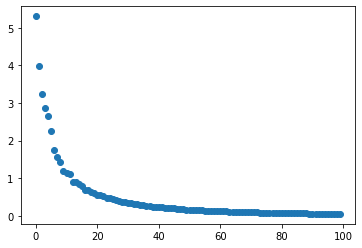

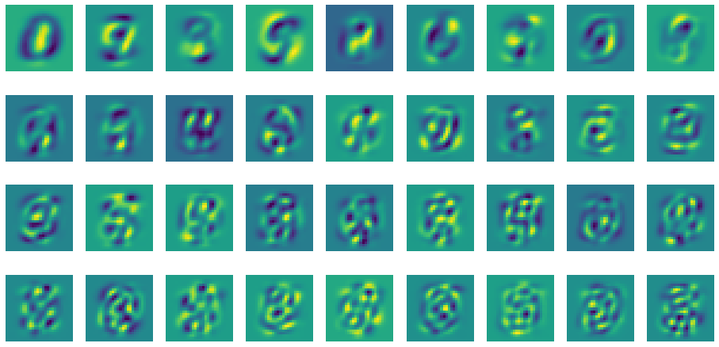

```python
######### P2 Handwritten digit features #############

### Data load
data = np.load('./HW2_data/digits-labels.npz')
X = data['d']

### PCA ###
X_cov = np.cov(X, bias =True)
print(X_cov.shape)
EigVal, EigVec = np.linalg.eigh(X_cov)

sort_ind = np.argsort(EigVal)[::-1]
EigVal_sort = EigVal[sort_ind]
EigVec_sort = EigVec[:,sort_ind]
Disp = 100
plt.figure(0)
plt.plot(EigVal_sort[:Disp],'o')

N_sel = 36

EigVec_sel = EigVec_sort[:,:N_sel]
SigmaInv_sel = np.diag(1/np.sqrt(EigVal_sort[:N_sel]))
W_sel = SigmaInv_sel@np.transpose(EigVec_sel)
X_sel = W_sel@X
print('Cov(Z) = \n',np.round(np.cov(Z_sel),2))
print(W_sel.shape)
plt.figure(1,figsize=(16,8))
for i in range(N_sel):
    plt.subplot(4,9,i+1)
    plt.imshow(reshape( W_sel[i,:],(28,28),'F'))
    plt.axis('off')
```

```
Cov(Y) =
 [[ 0.83 -0.01 -0.01 ...  0.01  0.02  0.01]
 [-0.01  0.86  0.02 ...  0.   -0.    0.01]
 [-0.01  0.02  0.92 ...  0.03  0.    0.01]
 ...
 [ 0.01  0.    0.03 ...  0.96 -0.03  0.  ]
 [ 0.02 -0.    0.   ... -0.03  0.94 -0.02]
 [ 0.01  0.01  0.01 ...  0.   -0.02  1.06]]
```

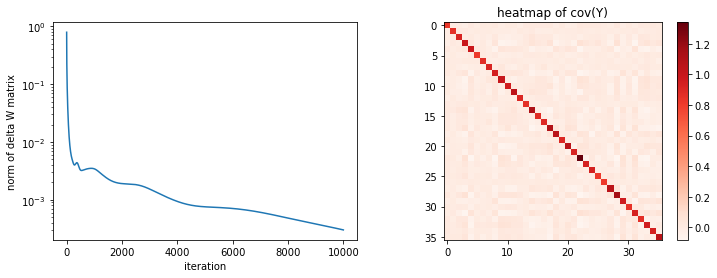

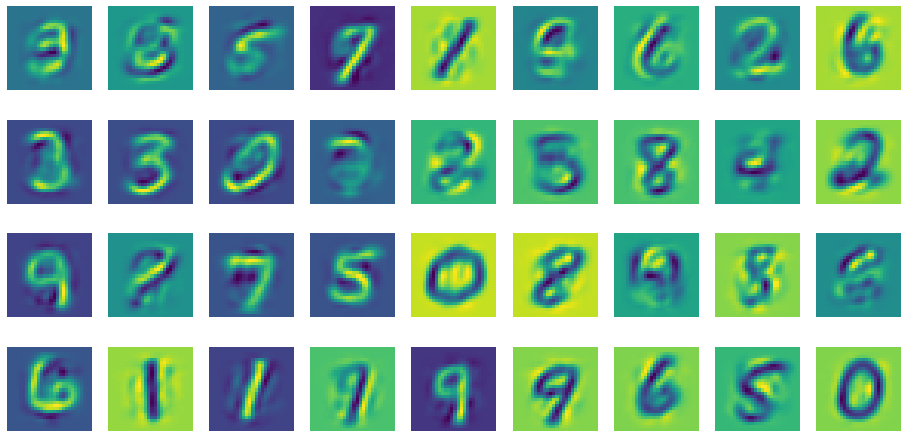

```python
##### P2 Handwritten digit features
### ICA ###
# Now, we start from X_sel from PCA output result.
# Y = W_ica X_sel
# where Y: Source estimates (36 x 10K), W_ica: feature matrix (36 x 36), X_sel: input matrix (36 x 10K)
N_iter = 10000
W_ica = np.random.rand(N_sel,N_sel) - 0.5
lr = 1e-6
N_t = len(X_sel[0,:])
dW_norm = []
for i in range(N_iter):
    dW = lr*(N_t*np.eye(N_sel)-2*np.tanh(W_ica@X_sel)@np.transpose(W_ica@X_sel))@W_ica
    W_ica = W_ica + dW
    dW_norm.append(np.linalg.norm(dW))
    #if i%100 == 99:
    #    lr = lr*0.9

Y = W_ica@X_sel

plt.figure(0,figsize=(12,4))
plt.subplot(1,2,1)
plt.plot(dW_norm)
plt.xlabel('iteration')
plt.ylabel('norm of delta W matrix')
plt.yscale('log')

plt.subplot(1,2,2)
plt.imshow(np.cov(Y),cmap='Reds')
plt.colorbar()
plt.title('heatmap of cov(Y)')


print('Cov(Y) = \n',np.round(np.cov(Y),2))
W_ip = W_ica@W_sel
A_ip = np.linalg.pinv(W_ip) ## Mixing matrix

plt.figure(1,figsize=(16,8))
for i in range(N_sel):
    plt.subplot(4,9,i+1)
    plt.imshow(reshape( A_ip[:,i],(28,28),'F'))
    plt.axis('off')
```

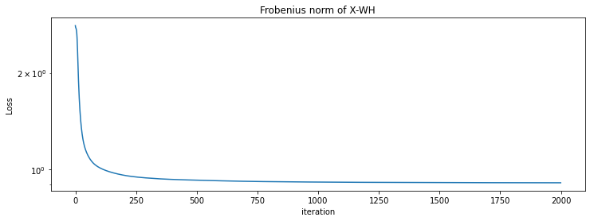

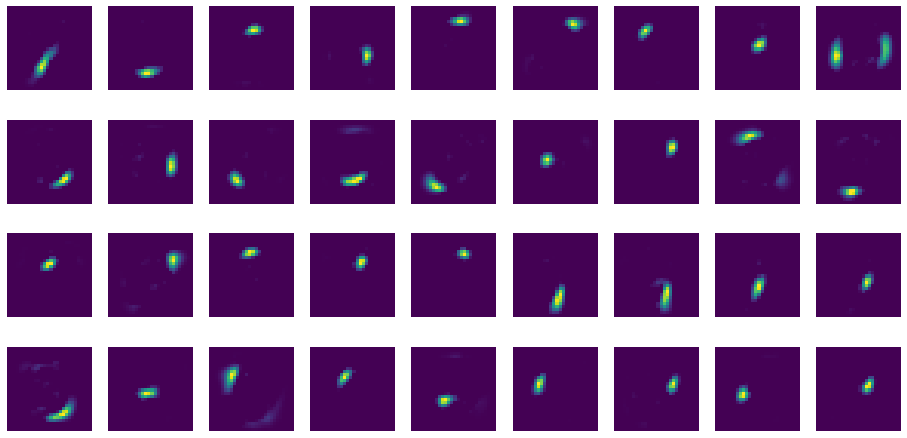

```python
##### P2.3: NMF #####
# This time, no need for PCA
# X = W_n H_n
# where X: Source estimates (513 x 349), W_n: feature matrix (513 x R), H_n: activation (R x 349)
N_sel = 36
## We pick R = N_sel ##
W_n = np.random.rand(len(X[:,0]),N_sel)
H_n = np.random.rand(N_sel,len(X[0,:]))
N_iter = 2000
N_t = len(X_sel[0,:])
NMF_norm = []
for i in range(N_iter):
    ## H update
    H_n = H_n*(np.transpose(W_n)@X)/(np.transpose(W_n)@W_n@H_n + 1e-6)    ## small number added in denominator

    ## W update
    W_n = W_n*(X@np.transpose(H_n))/(W_n@H_n@np.transpose(H_n) + 1e-6)

    ## norm save
    NMF_norm.append((np.linalg.norm(X-W_n@H_n)**2)/(513*349))

plt.figure(0,figsize=(12,4))
plt.plot(NMF_norm)
plt.xlabel('iteration')
plt.ylabel('Loss')
plt.yscale('log')
plt.title('Frobenius norm of X-WH')

plt.figure(1,figsize=(16,8))
for i in range(N_sel):
    plt.subplot(4,9,i+1)
    plt.imshow(reshape( W_n[:,i],(28,28),'F'))
    plt.axis('off')
```

Discussion on P2 (PCA, ICA, NMF):

- PCA feature credits most frequently-drawn parts the most across all images. Thus, that pattern itself does not make sense much.
- ICA will separate 36 dimensional data mixture acquired from PCA into separate independent images and mixing basis(independent component) should look like a mask that generates 36 dimensional data which applies onto the raw data. Thus, these mixing basis should look like numbers from 0 to 9 with some variations.
- NMF feature generally shows "additive components" which decomposes original number figures by fundamental parts. As can be seen from result, each feature represents some strokes of the number drawings and combinations of these strokes could make one of the complete numbers; thus, it makes sense.

[output not shown]

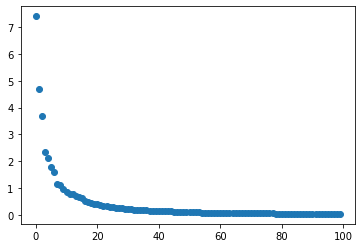

```python
######### P3 The geometry of handwritten digits #############

### Data load
data = np.load('./HW2_data/digits-labels.npz')
X = data['d']
L = data['l']

search_ind = np.argwhere(L==6).flatten()
X = X[:,search_ind]

### PCA ###
X_cov = np.cov(X, bias =True)
EigVal, EigVec = np.linalg.eigh(X_cov)

sort_ind = np.argsort(EigVal)[::-1]
EigVal_sort = EigVal[sort_ind]
EigVec_sort = EigVec[:,sort_ind]
Disp = 100
plt.figure(0)
plt.plot(EigVal_sort[:Disp],'o')

N_sel = 2

EigVec_sel = EigVec_sort[:,:N_sel]
SigmaInv_sel = np.diag(1/np.sqrt(EigVal_sort[:N_sel]))
W_sel = SigmaInv_sel@np.transpose(EigVec_sel)
X_sel = W_sel@X
print('Cov(Z) = \n',np.round(np.cov(Z_sel),2))

plt.figure(1,figsize=(16,8))
for i in range(N_sel):
    plt.subplot(4,9,i+1)
    plt.imshow(reshape( W_sel[i,:],(28,28),'F'))
    plt.axis('off')
```

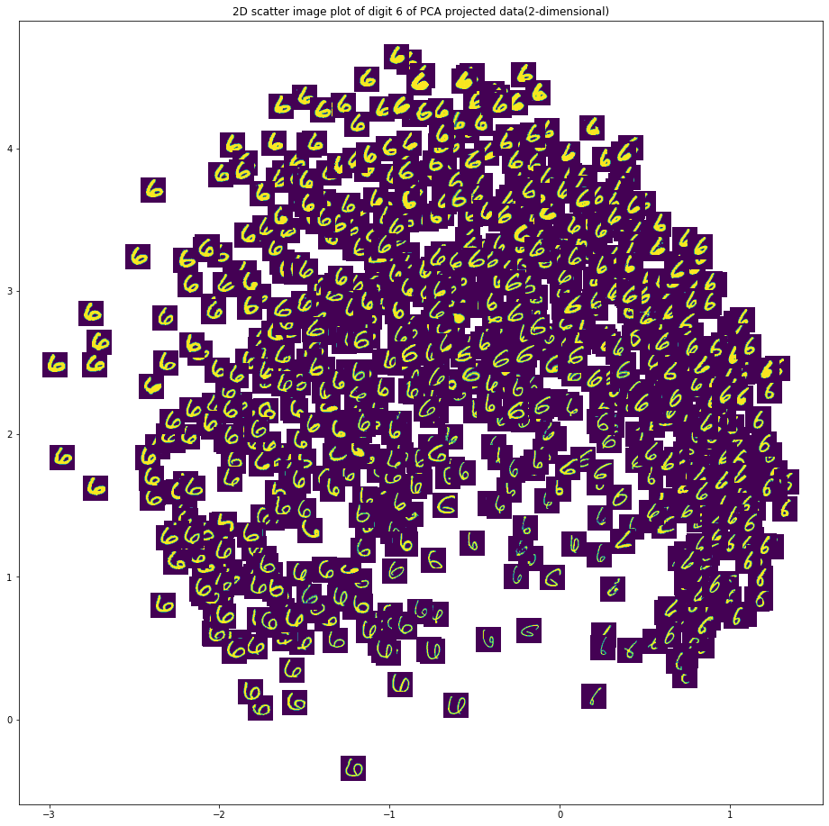

```python
#### P3. 1 scatter plot
fig, ax = plt.subplots(figsize=(16,16))
ax.scatter(X_sel[0,:], X_sel[1,:])
plt.title('2D scatter image plot of digit 6 of PCA projected data(2-dimensional)')
i=0
for x0, y0 in zip(X_sel[0,:], X_sel[1,:]):
    ax.add_artist(AnnotationBbox(OffsetImage(reshape( X[:,i],(28,28),'F') ), (x0, y0), frameon=False))
    i +=1
```

Comment: Looks like similar style of drawings is clustered together across (x,y) coordinates